# Stat 490 HW3

Janine Yanes

```r
#Load packages
library(knitr)
library(kableExtra)
library(tidyverse)
```

## Problem 1

```r
problem_1 = data.frame(
  Block.Age = c(rep(1,6), rep(2,6)),
  Unit = c(1:12),
  Y0 = c(NA, 99, NA, 97, 102, NA, NA, NA, 100, 99, 97, NA),
  Y1 = c(97, NA, 97, NA, NA, 99, 97, 98, NA, NA, NA, 101),
  W = c(1,0,1,0,0,1,1,1,0,0,0,1),
  y = c(97,99,97,97,102,99,97,98,100,99,97,101)
)

problem_1 %>%
    kable("html", align = 'clc', caption = 'Problem 1 table') %>%
      column_spec(1:2, bold = T, border_right = T) %>%
      column_spec(4:5, border_right = T) %>%
      row_spec(0, extra_css = "border-bottom: 1px solid;") %>%
      row_spec(6, extra_css = "border-bottom: 1px solid;") %>%
      kable_styling(full_width = T)
```

Problem 1 table

| Block.Age | Unit | Y0 | Y1 | W | y |
| --- | --- | --- | --- | --- | --- |
| 1 | 1 | NA | 97 | 1 | 97 |
| 1 | 2 | 99 | NA | 0 | 99 |
| 1 | 3 | NA | 97 | 1 | 97 |
| 1 | 4 | 97 | NA | 0 | 97 |
| 1 | 5 | 102 | NA | 0 | 102 |
| 1 | 6 | NA | 99 | 1 | 99 |
| 2 | 7 | NA | 97 | 1 | 97 |
| 2 | 8 | NA | 98 | 1 | 98 |
| 2 | 9 | 100 | NA | 0 | 100 |
| 2 | 10 | 99 | NA | 0 | 99 |
| 2 | 11 | 97 | NA | 0 | 97 |
| 2 | 12 | NA | 101 | 1 | 101 |

### a)

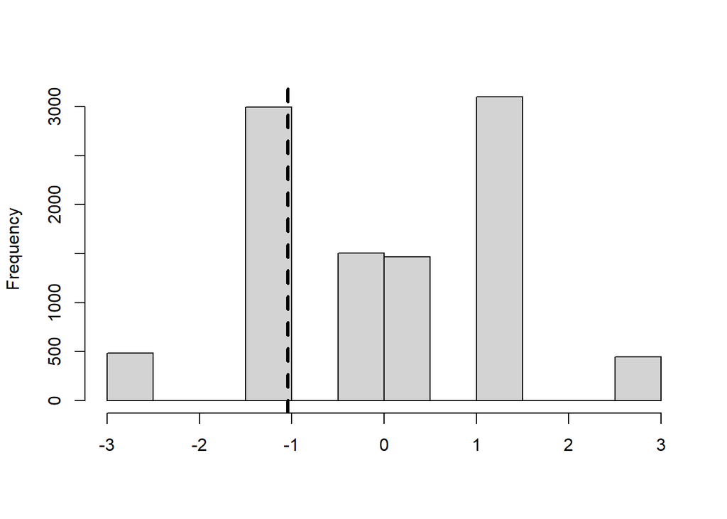

```r
set.seed(123)
p1_b1 = subset(problem_1, Block.Age == 1)

#Using code from class
Nbytwo <- function(y,w) {
  N = length(y)
  Ypot = matrix(numeric(N*2), ncol=2)
  for (i in 1:N) {
    if (w[i]==1) {
      Ypot[i,1] = NA
      Ypot[i,2] = y[i]
    }
    else {
      Ypot[i,1] = y[i]
      Ypot[i,2] = NA
    }
  }
  return(Ypot)
}

TUNEQUALCOMPUTE = function(y,w, taustar=0) {
  # Computes t statistic with unequal variances
  N = length(y)
  N1 = sum(w)
  N0 = N - N1
  tauhat = mean(y[w==1]) - mean(y[w==0])
  s0sq = var(y[w==0])
  s1sq = var(y[w==1])
  Tobs = (tauhat - taustar) / sqrt(s0sq/N0+s1sq/N1)
  return(Tobs)
}

TEQUALCOMPUTE = function(y,w, taustar=0) {
  # Computes t statistic with equal (pooled) variances
  N = length(y)
  N1 = sum(w)
  N0 = N - N1
  tauhat = mean(y[w==1]) - mean(y[w==0])
  s0sq = var(y[w==0])
  s1sq = var(y[w==1])
  ssq_pooled = ((N0-1)*s0sq + (N1-1)*s1sq)/(N0 + N1 -2)
  Tobs = (tauhat - taustar) / sqrt(ssq_pooled*(1/N0+1/N1))
  return(Tobs)
}

imputeundersharpnull = function(Y,taustar=0){
  N = dim(Y)[1]
  for (i in 1:N) {
    if (is.na(Y[i,1])) Y[i,1] = Y[i,2]-taustar
    else Y[i,2] = Y[i,1]+taustar
  }
  return(Y)
}

FISHER_TEST = function(y,w, taustar, ITER, tunequal=TRUE, show_hist=TRUE) {
  # Tests sharp null H0:tau_i=taustar against tau_i>taustar
  N = length(y) # Number of units
  Ypot = Nbytwo(y,w)
  if (tunequal==TRUE) Tobs = TUNEQUALCOMPUTE(y,w, taustar) # Calculate observed value of statistic
  else Tobs = TUNEQUALCOMPUTE(y,w, taustar)
  Yimp = imputeundersharpnull(Ypot, taustar) # Create imputed matrix of potential outcomes
  Tarray = NULL
  for (i in 1:ITER) {
    wnew = sample(w) # this command randomly permutes the sequence x
    ynew = numeric(N)
    for (i in 1:N) ynew[i]=Yimp[i,wnew[i]+1]
    if (tunequal==TRUE) Tnew = TUNEQUALCOMPUTE(ynew,wnew, taustar)
    else Tnew = TEQUALCOMPUTE(ynew,wnew, taustar)
    Tarray = c(Tarray, Tnew)
  }
  if (show_hist==TRUE) {
    hist(Tarray, main=NULL, xlab=NULL)
    abline(v=Tobs, lty=2, lwd=3.0)
  }
  # Calculate p-value for two-sided alternative
  pval_twosided = sum(abs(Tarray) >= abs(Tobs))/ITER
  return(cat("p =", pval_twosided))
}

FISHER_TEST(p1_b1$y, p1_b1$W, 0, 10000)
```

p = 0.7025

Given our large p-value, we fail to reject the null hypothesis.  
In other words, the test indicates that there is no differential treatment effect on any unit in Block 1.

### b)

```r
set.seed(123)
print(var(problem_1$Y0, na.rm = TRUE))
```

[1] 3.6

```r
print(var(problem_1$Y1, na.rm = TRUE))
```

[1] 2.566667

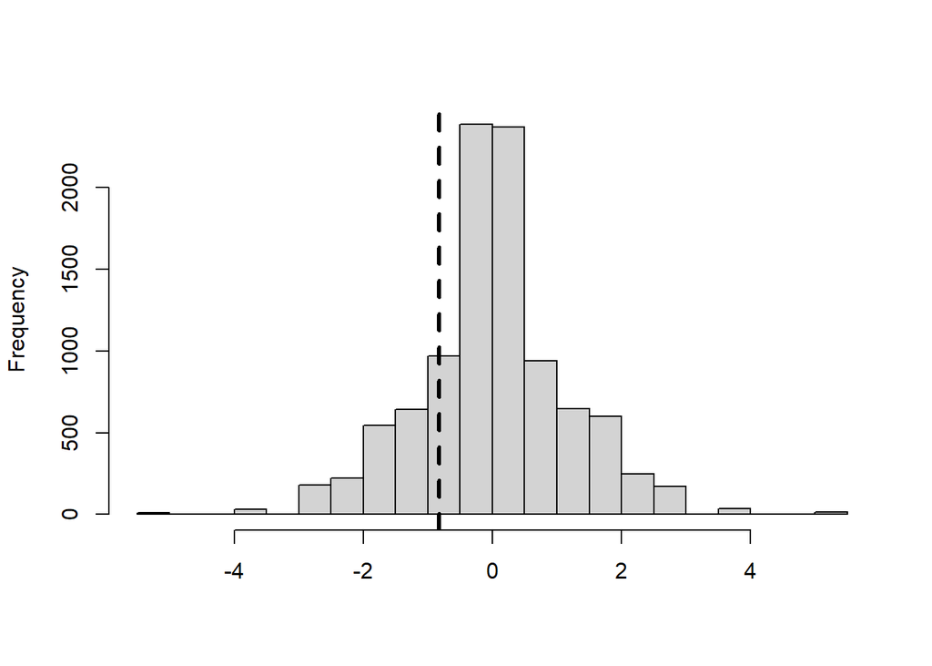

```r
FISHER_TEST(problem_1$y, problem_1$W, 0, 10000)
```

p = 0.4117

Since the two treatment groups have significantly different variances (3.6 for treatment group 0 vs. 2.566667 for treatment group 1), we use the test statistic $T_{\text{avg-uneqvar}}$ in order to have a test statistic that takes variability into account. Since we are looking for any treatment effect (whether positive or negative), we use a two-sided alternative.  
Given our large p-value, we fail to reject the null hypothesis.  
In other words, the test indicates that there is essentially zero treatment effect for each of the twelve participants.

### c)

```r
set.seed(123)
p1_b2 = subset(problem_1, Block.Age == 2)

#using code from class
Neymanian_inference = function(y,w, alpha){
  N = length(y)
  N1 = sum(w)
  N0 = N - N1
  tauhat = mean(y[w==1]) - mean(y[w==0])
  s0sq = var(y[w==0])
  s1sq = var(y[w==1])

  Tobs = TUNEQUALCOMPUTE(y,w)
  pval_minus = pnorm(Tobs)
  pval_plus = 1 - pval_minus
  pval_twosided = 2*(1 - pnorm(Tobs))

  LL <- Tobs - qnorm(1-alpha/2)*sqrt(s0sq/N0 + s1sq/N1)
  UL <- Tobs + qnorm(1-alpha/2)*sqrt(s0sq/N0 + s1sq/N1)

  return(list(Tobs=Tobs,
            pvalues=c(pval_plus,pval_minus,
            pval_twosided),CI=c(LL,UL)))
}

#modifying code from class
Neymanian_inference_blocks = function(yb1,yb2,wb1, wb2, alpha){
  Nb1 = length(yb1)
  Nb2 = length(yb2)
  N1b1 = sum(wb1)
  N0b1 = Nb1 - N1b1
  N1b2 = sum(wb2)
  N0b2 = Nb2 - N1b2

  tauhatb1 = mean(yb1[wb1==1]) - mean(yb1[wb1==0])
  tauhatb2 = mean(yb2[wb2==1]) - mean(yb2[wb2==0])
  taudiff = tauhatb1 - tauhatb2

  s0sqb1 = var(yb1[wb1==0])
  s1sqb1 = var(yb1[wb1==1])
  s0sqb2 = var(yb2[wb2==0])
  s1sqb2 = var(yb2[wb2==1])
  vardiff = s0sqb1/N0b1 + s1sqb1/N1b1 + s0sqb2/N0b2 + s0sqb2/N0b2

  Tobs = taudiff / sqrt(vardiff)
  pval_minus = pnorm(Tobs)
  pval_plus = 1 - pval_minus
  pval_twosided = 2*(1 - pnorm(Tobs))

  LL <- Tobs - qnorm(1-alpha/2)*sqrt(vardiff)
  UL <- Tobs + qnorm(1-alpha/2)*sqrt(vardiff)

  return(list(Tobs=Tobs,
            pvalues=c(pval_plus,pval_minus,
            pval_twosided),CI=c(LL,UL)))
}

b2_ci = Neymanian_inference(p1_b2$y, p1_b2$W, 0.05)$CI
cat("The 95% confidence interval for the average treatment effect within Block 2 is (", b2_ci[1],", ",b2_ci[2], ").", sep='' )
```

The 95% confidence interval for the average treatment effect within Block 2 is (-2.921742, 2.921742).

```r
bdiff_ci = Neymanian_inference_blocks(p1_b1$y, p1_b2$y, p1_b1$W,  p1_b2$W, 0.05)$CI
cat("The 95% confidence interval for the difference of the average treatment effects within Block 1 and Block 2 is (", bdiff_ci[1],", ",bdiff_ci[2], ").", sep='' )
```

The 95% confidence interval for the difference of the average treatment effects within Block 1 and Block 2 is (-4.795993, 3.152004).

## Problem 2

```r
problem_2 = data.frame(
  Group = c(1,1,2,2,3,3,4,4,5,5,6,6,7,7,8,8,9,9,10,10),
  Diet = rep(c("A","B"),5),
  y = c(13.2,14.0,8.2,8.8,10.9,11.2,14.3,14.2,10.7,11.8,6.6,6.4,9.5,9.8,10.8,11.3,8.8,9.3,13.3,13.6)
)

problem_2 %>%
    kable("html", align = 'clc', caption = 'Problem 2 table') %>%
      column_spec(1, bold = T, border_right = T) %>%
      column_spec(2, border_right = T) %>%
      row_spec(0, extra_css = "border-bottom: 1px solid;") %>%
      row_spec(c(2,4,6,8,10,12,14,16,18), extra_css = "border-bottom: 1px solid;") %>%
      kable_styling(full_width = T)
```

Problem 2 table

| Group | Diet | y |
| --- | --- | --- |
| 1 | A | 13.2 |
| 1 | B | 14.0 |
| 2 | A | 8.2 |
| 2 | B | 8.8 |
| 3 | A | 10.9 |
| 3 | B | 11.2 |
| 4 | A | 14.3 |
| 4 | B | 14.2 |
| 5 | A | 10.7 |
| 5 | B | 11.8 |
| 6 | A | 6.6 |
| 6 | B | 6.4 |
| 7 | A | 9.5 |
| 7 | B | 9.8 |
| 8 | A | 10.8 |
| 8 | B | 11.3 |
| 9 | A | 8.8 |
| 9 | B | 9.3 |
| 10 | A | 13.3 |
| 10 | B | 13.6 |

### i)

Given that the animals differ with respect to age, sex and so on, a completely randomized experiment could lead to all the animals with the same age/sex/etc. being in one treatment group. As a result, that characteristic would become a confounding variable; we would be unsure if any perceived effect (or lack of effect) would be due to the treatment or was influenced by the group’s common characteristic.

### ii)

There are $10(_2C_1) = 20$ possible randomizations in this experiment.

### iii)

One possible randomization is {A, A, B, B}, {A, A, B, B}, {A, A, B, B}, {A, A, B, B}, {A, A, B, B}. This would not be possible with a matched-pair design since both units in a pair cannot have the same assigned treatment.

### iv)

```r
problem_2_p4 = data.frame(
  Group = c(1,1,2,2,3,3,4,4,5,5,6,6,7,7,8,8,9,9,10,10),
  Diet = rep(c("A","B"),5),
  Y0 = c(NA,14.0,NA,8.8,NA,11.2,NA,14.2,NA,11.8,NA,6.4,NA,9.8,NA,11.3,NA,9.3,NA,13.6),
  Y1 = c(13.2,NA,8.2,NA,10.9,NA,14.3,NA,10.7,NA,6.6,NA,9.5,NA,10.8,NA,8.8,NA,13.3,NA),
  W = rep(c(1,0),5),
  y = c(13.2,14.0,8.2,8.8,10.9,11.2,14.3,14.2,10.7,11.8,6.6,6.4,9.5,9.8,10.8,11.3,8.8,9.3,13.3,13.6)
)

problem_2_p4 %>%
    kable("html", align = 'clc', caption = 'Problem 2 table, with observed and missing potential outcomes and observed assignment vector') %>%
      column_spec(1, bold = T, border_right = T) %>%
      column_spec(c(2,4,5), border_right = T) %>%
      row_spec(0, extra_css = "border-bottom: 1px solid;") %>%
      row_spec(c(2,4,6,8,10,12,14,16,18), extra_css = "border-bottom: 1px solid;") %>%
      kable_styling(full_width = T)
```

Problem 2 table, with observed and missing potential outcomes and observed assignment vector

| Group | Diet | Y0 | Y1 | W | y |
| --- | --- | --- | --- | --- | --- |
| 1 | A | NA | 13.2 | 1 | 13.2 |
| 1 | B | 14.0 | NA | 0 | 14.0 |
| 2 | A | NA | 8.2 | 1 | 8.2 |
| 2 | B | 8.8 | NA | 0 | 8.8 |
| 3 | A | NA | 10.9 | 1 | 10.9 |
| 3 | B | 11.2 | NA | 0 | 11.2 |
| 4 | A | NA | 14.3 | 1 | 14.3 |
| 4 | B | 14.2 | NA | 0 | 14.2 |
| 5 | A | NA | 10.7 | 1 | 10.7 |
| 5 | B | 11.8 | NA | 0 | 11.8 |
| 6 | A | NA | 6.6 | 1 | 6.6 |
| 6 | B | 6.4 | NA | 0 | 6.4 |
| 7 | A | NA | 9.5 | 1 | 9.5 |
| 7 | B | 9.8 | NA | 0 | 9.8 |
| 8 | A | NA | 10.8 | 1 | 10.8 |
| 8 | B | 11.3 | NA | 0 | 11.3 |
| 9 | A | NA | 8.8 | 1 | 8.8 |
| 9 | B | 9.3 | NA | 0 | 9.3 |
| 10 | A | NA | 13.3 | 1 | 13.3 |
| 10 | B | 13.6 | NA | 0 | 13.6 |

### v)

```r
set.seed(123)
print(var(problem_2_p4$Y0, na.rm = TRUE))
```

[1] 6.342667

```r
print(var(problem_2_p4$Y1, na.rm = TRUE))
```

[1] 6.009

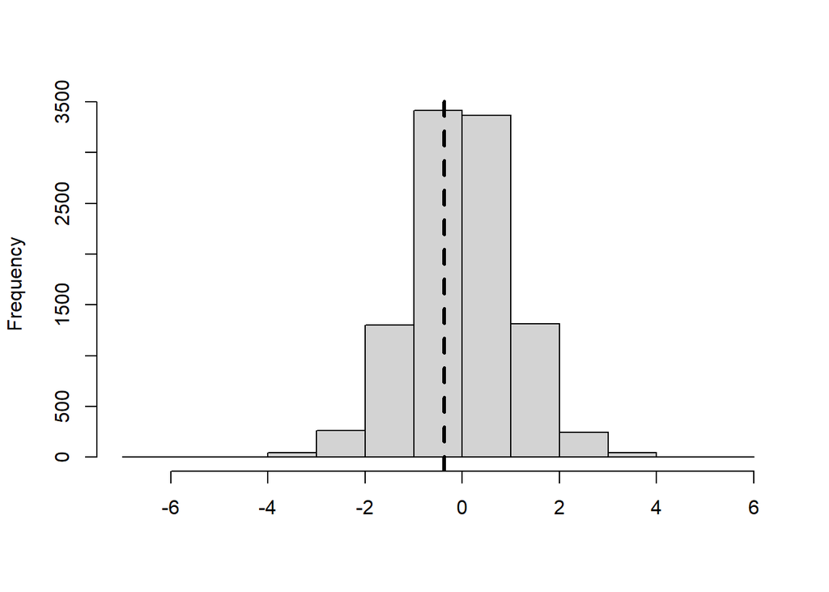

```r
#See Problem 1, part a) for function
#parameter tunequal is set to FALSE, so T_{avg-eqvar} is used
FISHER_TEST(problem_2_p4$y, problem_2_p4$W, 0, 10000, FALSE)
```

p = 0.7167

Since the two treatment groups have similar variances (6.342667 for treatment group 0 vs. 6.009 for treatment group 1), we use the test statistic $T_{\text{avg-eqvar}}$ in order to have a test statistic that takes variability into account. Since we are looking for any treatment effect (whether positive or negative), we use a two-sided alternative.  
Given our large p-value, we fail to reject the null hypothesis.  
In other words, the test indicates that there is essentially zero treatment effect for each of the twenty participants.

### vi)

```r
#See Problem 1, part c) for function
problem_2_ci = Neymanian_inference(problem_2_p4$y, problem_2_p4$W, 0.05)$CI
cat("The 95% confidence interval for the average causal effect is (", problem_2_ci[1],", ",problem_2_ci[2], ").", sep='' )
```

The 95% confidence interval for the average causal effect is (-2.547176, 1.809355).

## Problem 3

### a)

$$\hat{\bar\tau}_b = \bar y_b(1) - \bar
y_b(0) \to E[\hat{\bar\tau}_b] = E[\bar y_b(1) - \bar y_b(0)] = E[\bar
y_b(1)] - E[\bar y_b(0)] = \bar Y_b(1) - \bar Y_b(0) =
\bar\tau_b$$
Therefore, $\hat{\bar\tau}_b$ is an unbiased estimator of $\bar\tau_b$.

### b)

An unbiased estimator for $\bar\tau$ would be $\frac{1}{B}\sum_{b=1}^B\hat{\bar\tau}_b$.
Let $M_b$ be the block size for block $b$ (in this case, $M_b$ = 2 for every block and $N=2b$):
$$E[\frac{1}{B}\sum_{b=1}^B\hat{\bar\tau}_b] =
\frac{1}{B}(E[\hat{\bar\tau}_1] + E[\hat{\bar\tau}_2] + \dots +
E[\hat{\bar\tau}_B]) = \frac{1}{B}\sum_{b=1}^B\bar\tau_b =
\frac{1}{2B}\sum_{b=1}^B2\bar\tau_b =
\frac{1}{N}\sum_{b=1}^BM_b\bar\tau_b = \bar\tau$$
$E[\frac{1}{B}\sum_{b=1}^B\hat{\bar\tau}_b] = \bar\tau$ as defined in (3.3) (in Section 3.2.1 of the textbook), so $\frac{1}{B}\sum_{b=1}^B\hat{\bar\tau}_b$ is an unbiased estimator of $\bar\tau$.